# Project: Investigate Medical no-show appointments dataset

- Introduction
- Data Wrangling
- Exploratory Data Analysis
- Conclusions

## Introduction

This dataset collects information from 100k medical appointments in Brazil and is focused on the question of whether or not patients show up for their appointment. A number of characteristics about the patient are included in each row.

**Questions that we will answer:**

- Does receiving an SMS encourage the patient go to the appointment?
- Does gender affect the attendance rate?
- Does Age affect the attendance rate?
- Does Neighbourhood affect the attendance rate?
- How does variables correlate to each other

```python
import pandas as pd
import numpy as np
import seaborn as sns
import matplotlib.pyplot as plt
%matplotlib inline
```

## Data Wrangling

> **Tip**: In this section of the report, you will load in the data, check for cleanliness, and then trim and clean your dataset for analysis. Make sure that you document your steps carefully and justify your cleaning decisions.

### General Properties

```python
# Load the data
df = pd.read_csv('KaggleV2-May-2016.csv')
df.head()
```

|  | PatientId | AppointmentID | Gender | ScheduledDay | AppointmentDay | Age | Neighbourhood | Scholarship | Hipertension | Diabetes | Alcoholism | Handcap | SMS_received | No-show |
| --- | --- | --- | --- | --- | --- | --- | --- | --- | --- | --- | --- | --- | --- | --- |
| 0 | 2.987250e+13 | 5642903 | F | 2016-04-29T18:38:08Z | 2016-04-29T00:00:00Z | 62 | JARDIM DA PENHA | 0 | 1 | 0 | 0 | 0 | 0 | No |
| 1 | 5.589978e+14 | 5642503 | M | 2016-04-29T16:08:27Z | 2016-04-29T00:00:00Z | 56 | JARDIM DA PENHA | 0 | 0 | 0 | 0 | 0 | 0 | No |
| 2 | 4.262962e+12 | 5642549 | F | 2016-04-29T16:19:04Z | 2016-04-29T00:00:00Z | 62 | MATA DA PRAIA | 0 | 0 | 0 | 0 | 0 | 0 | No |
| 3 | 8.679512e+11 | 5642828 | F | 2016-04-29T17:29:31Z | 2016-04-29T00:00:00Z | 8 | PONTAL DE CAMBURI | 0 | 0 | 0 | 0 | 0 | 0 | No |
| 4 | 8.841186e+12 | 5642494 | F | 2016-04-29T16:07:23Z | 2016-04-29T00:00:00Z | 56 | JARDIM DA PENHA | 0 | 1 | 1 | 0 | 0 | 0 | No |

```python
# Figuring out the size of the data
df.shape
```

```
(110527, 14)
```

```python
# Types of data in columns and looking for missing values
df.info()
```

```
<class 'pandas.core.frame.DataFrame'>
RangeIndex: 110527 entries, 0 to 110526
Data columns (total 14 columns):
 #   Column          Non-Null Count   Dtype
---  ------          --------------   -----
 0   PatientId       110527 non-null  float64
 1   AppointmentID   110527 non-null  int64
 2   Gender          110527 non-null  object
 3   ScheduledDay    110527 non-null  object
 4   AppointmentDay  110527 non-null  object
 5   Age             110527 non-null  int64
 6   Neighbourhood   110527 non-null  object
 7   Scholarship     110527 non-null  int64
 8   Hipertension    110527 non-null  int64
 9   Diabetes        110527 non-null  int64
 10  Alcoholism      110527 non-null  int64
 11  Handcap         110527 non-null  int64
 12  SMS_received    110527 non-null  int64
 13  No-show         110527 non-null  object
dtypes: float64(1), int64(8), object(5)
memory usage: 11.8+ MB
```

No missing values

```python
# looking for duplicated rows
df.duplicated().any()
```

```
False
```

```python
# info about the data
df.describe()
```

|  | PatientId | AppointmentID | Age | Scholarship | Hipertension | Diabetes | Alcoholism | Handcap | SMS_received |
| --- | --- | --- | --- | --- | --- | --- | --- | --- | --- |
| count | 1.105270e+05 | 1.105270e+05 | 110527.000000 | 110527.000000 | 110527.000000 | 110527.000000 | 110527.000000 | 110527.000000 | 110527.000000 |
| mean | 1.474963e+14 | 5.675305e+06 | 37.088874 | 0.098266 | 0.197246 | 0.071865 | 0.030400 | 0.022248 | 0.321026 |
| std | 2.560949e+14 | 7.129575e+04 | 23.110205 | 0.297675 | 0.397921 | 0.258265 | 0.171686 | 0.161543 | 0.466873 |
| min | 3.921784e+04 | 5.030230e+06 | -1.000000 | 0.000000 | 0.000000 | 0.000000 | 0.000000 | 0.000000 | 0.000000 |
| 25% | 4.172614e+12 | 5.640286e+06 | 18.000000 | 0.000000 | 0.000000 | 0.000000 | 0.000000 | 0.000000 | 0.000000 |
| 50% | 3.173184e+13 | 5.680573e+06 | 37.000000 | 0.000000 | 0.000000 | 0.000000 | 0.000000 | 0.000000 | 0.000000 |
| 75% | 9.439172e+13 | 5.725524e+06 | 55.000000 | 0.000000 | 0.000000 | 0.000000 | 0.000000 | 0.000000 | 1.000000 |
| max | 9.999816e+14 | 5.790484e+06 | 115.000000 | 1.000000 | 1.000000 | 1.000000 | 1.000000 | 4.000000 | 1.000000 |

According to the information above, the average age among patients is 37 , the maximum age is 115 and the minimum age is -1 (Mistake)

### Removing unimportant columns and fixing errors

```python
# looking for the mistake
mistake = df.query('Age == -1')
mistake
```

|  | PatientId | AppointmentID | Gender | ScheduledDay | AppointmentDay | Age | Neighbourhood | Scholarship | Hipertension | Diabetes | Alcoholism | Handcap | SMS_received | No-show |
| --- | --- | --- | --- | --- | --- | --- | --- | --- | --- | --- | --- | --- | --- | --- |
| 99832 | 4.659432e+14 | 5775010 | F | 2016-06-06T08:58:13Z | 2016-06-06T00:00:00Z | -1 | ROMÃO | 0 | 0 | 0 | 0 | 0 | 0 | No |

```python
# Deleting the row with the wrong value
df.drop(index=99832,inplace=True)
```

```python
df.describe()
```

|  | PatientId | AppointmentID | Age | Scholarship | Hipertension | Diabetes | Alcoholism | Handcap | SMS_received |
| --- | --- | --- | --- | --- | --- | --- | --- | --- | --- |
| count | 1.105260e+05 | 1.105260e+05 | 110526.000000 | 110526.000000 | 110526.000000 | 110526.000000 | 110526.000000 | 110526.000000 | 110526.000000 |
| mean | 1.474934e+14 | 5.675304e+06 | 37.089219 | 0.098266 | 0.197248 | 0.071865 | 0.030400 | 0.022248 | 0.321029 |
| std | 2.560943e+14 | 7.129544e+04 | 23.110026 | 0.297676 | 0.397923 | 0.258266 | 0.171686 | 0.161543 | 0.466874 |
| min | 3.921784e+04 | 5.030230e+06 | 0.000000 | 0.000000 | 0.000000 | 0.000000 | 0.000000 | 0.000000 | 0.000000 |
| 25% | 4.172536e+12 | 5.640285e+06 | 18.000000 | 0.000000 | 0.000000 | 0.000000 | 0.000000 | 0.000000 | 0.000000 |
| 50% | 3.173184e+13 | 5.680572e+06 | 37.000000 | 0.000000 | 0.000000 | 0.000000 | 0.000000 | 0.000000 | 0.000000 |
| 75% | 9.438963e+13 | 5.725523e+06 | 55.000000 | 0.000000 | 0.000000 | 0.000000 | 0.000000 | 0.000000 | 1.000000 |
| max | 9.999816e+14 | 5.790484e+06 | 115.000000 | 1.000000 | 1.000000 | 1.000000 | 1.000000 | 4.000000 | 1.000000 |

```python
# Deleting unimportant columns like PatientId,AppointmentID	, AppointmentDay and ScheduledDay
df.drop(['PatientId','AppointmentID','AppointmentDay','ScheduledDay'],axis=1,inplace=True)
df.head()
```

|  | Gender | Age | Neighbourhood | Scholarship | Hipertension | Diabetes | Alcoholism | Handcap | SMS_received | No-show |
| --- | --- | --- | --- | --- | --- | --- | --- | --- | --- | --- |
| 0 | F | 62 | JARDIM DA PENHA | 0 | 1 | 0 | 0 | 0 | 0 | No |
| 1 | M | 56 | JARDIM DA PENHA | 0 | 0 | 0 | 0 | 0 | 0 | No |
| 2 | F | 62 | MATA DA PRAIA | 0 | 0 | 0 | 0 | 0 | 0 | No |
| 3 | F | 8 | PONTAL DE CAMBURI | 0 | 0 | 0 | 0 | 0 | 0 | No |
| 4 | F | 56 | JARDIM DA PENHA | 0 | 1 | 1 | 0 | 0 | 0 | No |

```python
# fixing the hypertension column name
df.rename(columns={'Hipertension':'Hypertension'},inplace=True)
df.head()
```

|  | Gender | Age | Neighbourhood | Scholarship | Hypertension | Diabetes | Alcoholism | Handcap | SMS_received | No-show |
| --- | --- | --- | --- | --- | --- | --- | --- | --- | --- | --- |
| 0 | F | 62 | JARDIM DA PENHA | 0 | 1 | 0 | 0 | 0 | 0 | No |
| 1 | M | 56 | JARDIM DA PENHA | 0 | 0 | 0 | 0 | 0 | 0 | No |
| 2 | F | 62 | MATA DA PRAIA | 0 | 0 | 0 | 0 | 0 | 0 | No |
| 3 | F | 8 | PONTAL DE CAMBURI | 0 | 0 | 0 | 0 | 0 | 0 | No |
| 4 | F | 56 | JARDIM DA PENHA | 0 | 1 | 1 | 0 | 0 | 0 | No |

```python
# Fixing the no show column name to be more suitable for analysis
df.rename(columns={'No-show':'No_show'},inplace=True)
df.head()
```

|  | Gender | Age | Neighbourhood | Scholarship | Hypertension | Diabetes | Alcoholism | Handcap | SMS_received | No_show |
| --- | --- | --- | --- | --- | --- | --- | --- | --- | --- | --- |
| 0 | F | 62 | JARDIM DA PENHA | 0 | 1 | 0 | 0 | 0 | 0 | No |
| 1 | M | 56 | JARDIM DA PENHA | 0 | 0 | 0 | 0 | 0 | 0 | No |
| 2 | F | 62 | MATA DA PRAIA | 0 | 0 | 0 | 0 | 0 | 0 | No |
| 3 | F | 8 | PONTAL DE CAMBURI | 0 | 0 | 0 | 0 | 0 | 0 | No |
| 4 | F | 56 | JARDIM DA PENHA | 0 | 1 | 1 | 0 | 0 | 0 | No |

## Exploratory Data Analysis

Now that we've trimmed and cleaned the data, we're ready to move on to exploration. using visualizations to answer questions

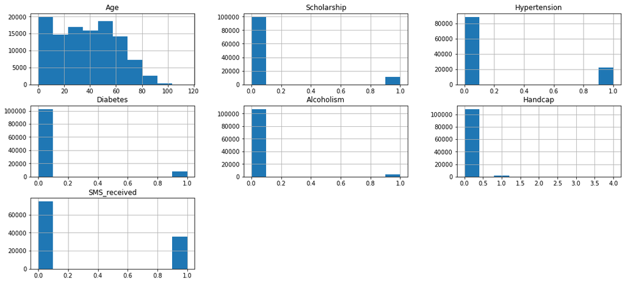

```python
# Histograms of all columns in the dataset
df.hist(figsize=(18,8));
```

## Does receiving an SMS encourage the patient go to the appointment?

```python
df['SMS_received'].value_counts()
```

```
0    75044
1    35482
Name: SMS_received, dtype: int64
```

The number of patients who received an SMS are nearly half the number of patients who didn't receive an SMS

```python
# we make two datasets, one that contains patients who received SMS and the other one contains patients who didn't receive an SMS
sms = df.query('SMS_received == 1')
no_sms = df.query('SMS_received == 0')
```

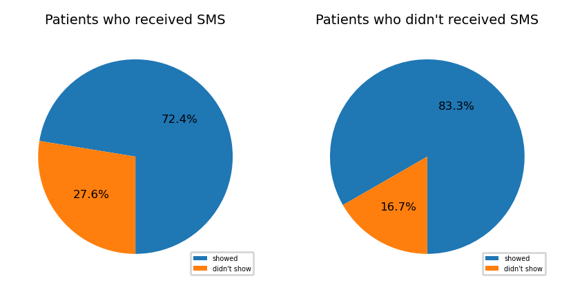

```python
# making pie charts to draw conclusions
fig = plt.figure(figsize=(5,5), dpi=200)
ax1 = fig.add_subplot(121)
sms['No_show'].value_counts().plot(kind='pie',ax=ax1,autopct='%1.1f%%',startangle=270, fontsize=6,labels= None,subplots=True)
plt.title('Patients who received SMS',fontsize=7)
plt.ylabel('')
plt.legend(loc=4,prop={'size': 3.5},labels=["showed","didn't show"])
ax2 = fig.add_subplot(122)
no_sms['No_show'].value_counts().plot(kind='pie',ax=ax2,autopct='%1.1f%%',startangle=270, fontsize=6,labels= None,subplots=True)
plt.title("Patients who didn't received SMS",fontsize=7)
plt.ylabel('')
plt.legend(loc=4,prop={'size': 3.5},labels=["showed","didn't show"])
plt.show()
```

We conclude that 83.3% of the patients who didn't receive an SMS showed for their appointment, while only 72.4% of the patients who received an SMS showed for their appointment. That is quite odd as one might think that receiving an SMS will encourage the patient to commit to their appointment.

## Does gender affect the attendance rate?

```python
# Create two datasets to identify who showed for their appointment and who didn't
show = df.query('No_show=="No"')
noshow = df.query('No_show=="Yes"')
```

```python
# create functions that return specific coulmns from show and noshow datasets
def showed(variable):
    return show[variable]
def no_show(variable):
    return noshow[variable]
```

```python
show['Gender'].value_counts()
```

```
F    57245
M    30962
Name: Gender, dtype: int64
```

```python
noshow['Gender'].value_counts()
```

```
F    14594
M     7725
Name: Gender, dtype: int64
```

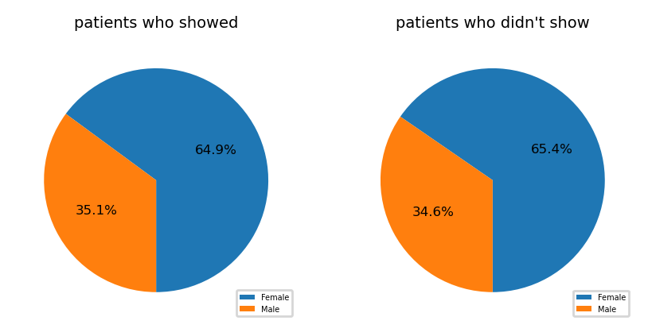

```python
# making pie charts to visualize the gender of people who showed and people who didn't show
fig = plt.figure(figsize=(5,5), dpi=200)
ax1 = fig.add_subplot(121)
showed('Gender').value_counts().plot(kind='pie',ax=ax1,autopct='%1.1f%%',startangle=270, fontsize=6,labels= None,subplots=True)
plt.title('patients who showed',fontsize=7)
plt.ylabel('')
plt.legend(loc=4,prop={'size': 3.5},labels=["Female","Male"])
ax2 = fig.add_subplot(122)
no_show('Gender').value_counts().plot(kind='pie',ax=ax2,autopct='%1.1f%%',startangle=270, fontsize=6,labels= None,subplots=True)
plt.title("patients who didn't show",fontsize=7)
plt.ylabel('')
plt.legend(loc=4,prop={'size': 3.5},labels=["Female","Male"])
plt.show()
```

We see that the decision of the patient to show or not isn't affected much by the patients gender, as the percentages of males and females who showed or didn't show are quite similar.

## Does Age affect the attendance rate?

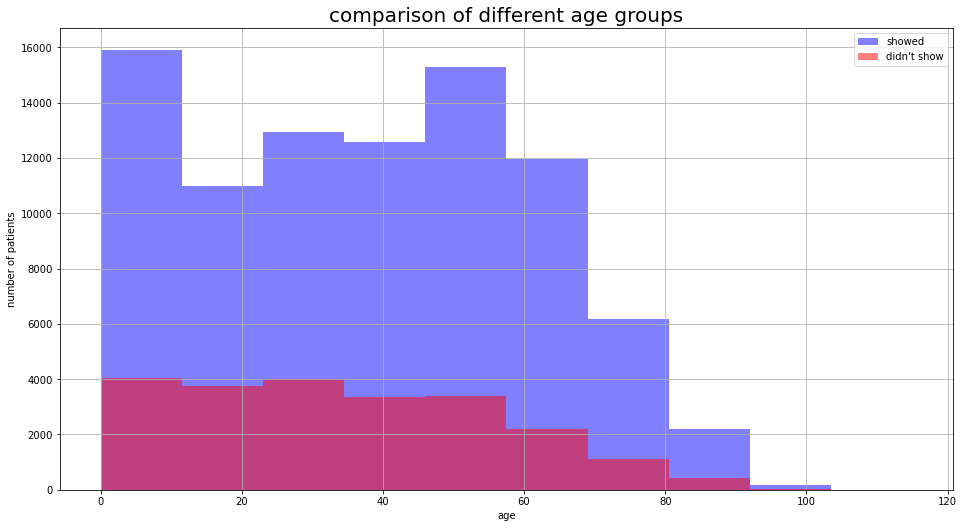

```python
# visualize the attendance rates of different age groups
plt.figure(figsize=(16,8.5))
showed('Age').plot(kind='hist',alpha=.5,color='blue',label='showed')
no_show('Age').plot(kind='hist',alpha=.5,color='red',label="didn't show")
plt.legend()
plt.title("comparison of different age groups",fontsize=20)
plt.xlabel('age')
plt.ylabel('number of patients')
plt.grid()
plt.show()
```

## Does Neighbourhood affect the attendance rate?

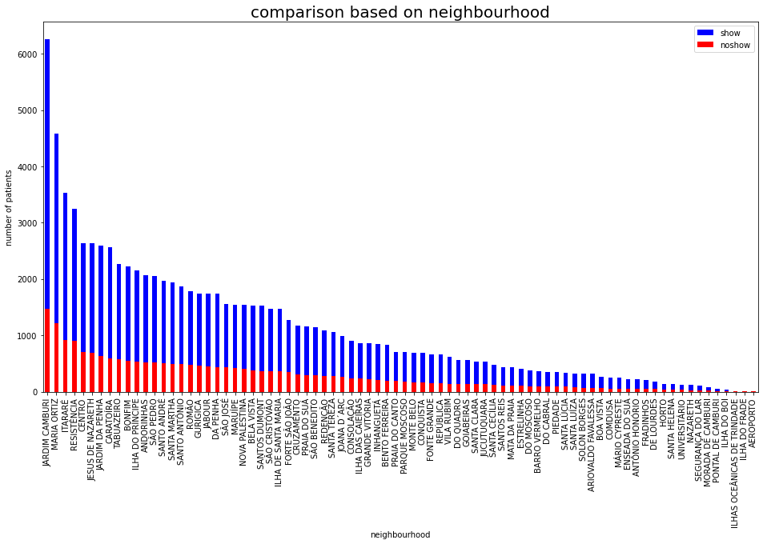

```python
# compare patients based on their neighbourhood
plt.figure(figsize=(16,8.5))
showed('Neighbourhood').value_counts().plot(kind='bar',alpha=1,color='blue',label='show')
no_show('Neighbourhood').value_counts().plot(kind='bar',alpha=1,color='red',label='noshow')
plt.legend()
plt.title('comparison based on neighbourhood',fontsize=20)
plt.ylabel('number of patients')
plt.xlabel('neighbourhood')
plt.show()
```

## How does variables correlate to each other?

```python
# first, we create a general profile of the data
import pandas_profiling as pf
profile = pf.ProfileReport(df,title='Profile report of the data',html={'style':{'full_width':True}})
profile
```

[interactive chart not shown]

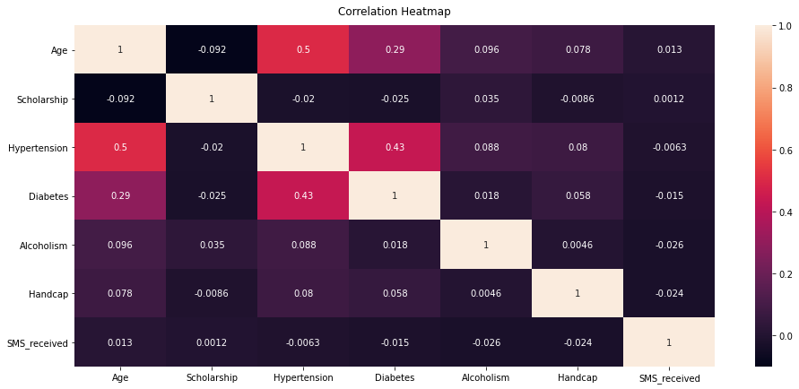

```python
#  now We create only a correlation heatmap of the dataset
plt.figure(figsize=(16, 7))
corr_map = sns.heatmap(df.corr(),vmin=-0.1, vmax=1, annot=True)
corr_map.set_title('Correlation Heatmap', fontdict={'fontsize':12}, pad=12);
plt.show()
```

From the map above, we can see that some variables are positively correlated like age and diabetes, age and hypertension, and hypertension and diabetes

# Limitations

The data are collected unevenly between different neighbourhoods, some neighbourhoods have a lot bigger numbers of patients than other neigbourhoods. Also, alot of patients age values are 0.